# BIOSTAT 707 Checkpoint 2: Feature Engineering and Supervised Modeling

Author

Jiahui Hu (jh1029)

Published

October 11, 2026

# AI-use statement

I used OpenAI Codex to assist with translating the assignment requirements into an analysis workflow, drafting portions of the R code, and troubleshooting implementation errors. I ran the complete analysis, reviewed the code, tables, figures, and statistical interpretations, and verified that the required cross-validation and data-use constraints were followed. I take responsibility for the final submission and conclusions.

```r
suppressPackageStartupMessages({
  library(data.table)
  library(dplyr)
  library(tidyr)
  library(readr)
  library(ggplot2)
  library(glmnet)
  library(mgcv)
  library(ranger)
  library(pROC)
  library(knitr)
})

here::i_am("checkpoint2.qmd")
set.seed(70702)

data_dir     <- here::here("data")
set_a_dir    <- here::here("data", "set-a")
outcomes_csv <- here::here("data", "Outcomes-a.txt")
out_dir      <- here::here("output")
dir.create(out_dir, recursive = TRUE, showWarnings = FALSE)

expected_n <- 4000L
outer_k <- 5L
inner_k <- 3L
rare_measurement_threshold <- 0.10
lambda_grid <- 10^seq(0, -4, length.out = 30)
rf_num_trees <- 250L

theme_set(
  theme_minimal(base_size = 12) +
    theme(panel.grid.minor = element_blank())
)
```

# 2.1 Modeling table

Checkpoint 2 uses **set-a only**. The modeling table has one row per ICU stay, so no stay can appear in both training and validation within a fold. Repeated measurements are summarized over hours 0–48. The binary outcome is in-hospital death from `Outcomes-a.txt`.

The data are from the PhysioNet/Computing in Cardiology Challenge 2012, “Predicting Mortality of ICU Patients” (Silva, Moody, Scott, Celi, and Mark, 2012), released under the Open Data Commons Attribution License. The dataset and its attribution information are available from [PhysioNet](https://physionet.org/content/challenge-2012/1.0.0/), and the study description is available from [PubMed Central](https://pmc.ncbi.nlm.nih.gov/articles/PMC3965265/).

```r
if (!dir.exists(set_a_dir)) stop("Missing data/set-a/")
if (!file.exists(outcomes_csv)) stop("Missing data/Outcomes-a.txt")

set_a_files <- sort(list.files(
  set_a_dir,
  pattern = "^[0-9]+\\.txt$",
  full.names = TRUE
))

if (length(set_a_files) != expected_n) {
  stop("Expected 4000 set-a files; found ", length(set_a_files))
}

time_to_minutes <- function(x) {
  parts <- strsplit(x, ":", fixed = TRUE)
  vapply(parts, function(z) {
    if (length(z) != 2L) return(NA_real_)
    60 * as.numeric(z[[1]]) + as.numeric(z[[2]])
  }, numeric(1))
}

load_one_record <- function(path) {
  file_id <- as.integer(sub("\\.txt$", "", basename(path)))
  x <- data.table::fread(path, showProgress = FALSE)
  names(x) <- trimws(names(x))
  stopifnot(all(c("Time", "Parameter", "Value") %in% names(x)))
  x[, Parameter := trimws(as.character(Parameter))]
  x[, Time := trimws(as.character(Time))]
  x[, Value := as.numeric(Value)]

  embedded_id <- x[Parameter == "RecordID", Value]
  if (length(embedded_id) != 1L || as.integer(embedded_id[[1]]) != file_id) {
    stop("RecordID does not match filename: ", path)
  }

  x <- x[Parameter != "RecordID"]
  x[, RecordID := file_id]
  x[, .(
    RecordID,
    Time,
    Minutes = time_to_minutes(Time),
    Parameter,
    Value_raw = Value
  )]
}

long_raw <- data.table::rbindlist(
  lapply(set_a_files, load_one_record),
  use.names = TRUE
) |>
  as_tibble()

if (anyNA(long_raw$Minutes)) stop("At least one Time value could not be parsed")

outcomes <- readr::read_csv(
  outcomes_csv,
  show_col_types = FALSE,
  progress = FALSE
)
names(outcomes) <- gsub("[^A-Za-z0-9]+", "_", names(outcomes))
names(outcomes) <- gsub("_+$", "", names(outcomes))

required_outcomes <- c(
  "RecordID", "SAPS_I", "SOFA", "Length_of_stay",
  "Survival", "In_hospital_death"
)
if (!all(required_outcomes %in% names(outcomes))) {
  stop("Unexpected Outcomes-a.txt columns")
}

outcomes <- outcomes |>
  mutate(
    RecordID = as.integer(RecordID),
    In_hospital_death = as.integer(In_hospital_death)
  )

stopifnot(
  nrow(outcomes) == expected_n,
  !anyDuplicated(outcomes$RecordID),
  setequal(long_raw$RecordID, outcomes$RecordID),
  all(outcomes$In_hospital_death %in% c(0L, 1L))
)
```

The cleaning rules carry forward the Checkpoint 1 decisions. The sentinel value -1 is treated as missing. Zero or clearly impossible height and weight values and selected measurements outside deliberately broad data-quality bounds are retained in the raw column but excluded from model summaries. These bounds are screens for obvious data problems, not clinical reference ranges.

```r
quality_bounds <- tribble(
  ~Parameter,    ~lower, ~upper,
  "Age",             0,    130,
  "Gender",          0,      1,
  "Height",         50,    250,
  "ICUType",         1,      4,
  "Weight",         20,    400,
  "Albumin",         0,     20,
  "ALP",             0,   5000,
  "ALT",             0,  20000,
  "AST",             0,  20000,
  "Bilirubin",       0,    100,
  "BUN",             0,    300,
  "Cholesterol",     0,   1000,
  "Creatinine",      0,     30,
  "DiasABP",         0,    250,
  "FiO2",            0,      1,
  "GCS",             3,     15,
  "Glucose",         0,   2000,
  "HCO3",            0,    100,
  "HCT",             0,    100,
  "HR",              0,    300,
  "K",               0,     15,
  "Lactate",         0,     40,
  "MAP",             0,    250,
  "MechVent",        0,      1,
  "Mg",              0,     20,
  "Na",             80,    220,
  "NIDiasABP",       0,    250,
  "NIMAP",           0,    250,
  "NISysABP",        0,    300,
  "PaCO2",           0,    300,
  "PaO2",            0,    800,
  "pH",              0,     14,
  "Platelets",       0,   2000,
  "RespRate",        0,    100,
  "SaO2",            0,    100,
  "SysABP",          0,    300,
  "Temp",           25,     45,
  "TroponinI",       0,   1000,
  "TroponinT",       0,   1000,
  "Urine",           0,  10000,
  "WBC",             0,    500
)

long <- long_raw |>
  left_join(quality_bounds, by = "Parameter") |>
  mutate(
    Value = if_else(Value_raw == -1, NA_real_, Value_raw),
    implausible =
      !is.na(Value) & !is.na(lower) & !is.na(upper) &
      (Value < lower | Value > upper),
    Value_clean = if_else(implausible | !is.finite(Value), NA_real_, Value)
  ) |>
  arrange(RecordID, Minutes, Parameter)

first_nonmissing <- function(x) {
  y <- x[!is.na(x)]
  if (length(y) == 0L) NA_real_ else y[[1]]
}

static_parameters <- c("Age", "Gender", "Height", "ICUType", "Weight")

static <- long |>
  filter(Parameter %in% static_parameters) |>
  group_by(RecordID, Parameter) |>
  summarise(Value = first_nonmissing(Value_clean), .groups = "drop") |>
  pivot_wider(
    id_cols = RecordID,
    names_from = Parameter,
    values_from = Value,
    names_repair = "check_unique"
  )

long_48 <- long |>
  filter(
    between(Minutes, 0, 48 * 60),
    !Parameter %in% static_parameters,
    !is.na(Value_clean)
  )

parameter_availability <- long_48 |>
  distinct(RecordID, Parameter) |>
  count(Parameter, name = "stays_measured") |>
  mutate(
    percent_measured = 100 * stays_measured / expected_n,
    keep = stays_measured / expected_n >= rare_measurement_threshold
  ) |>
  arrange(percent_measured)

kept_parameters <- parameter_availability |>
  filter(keep) |>
  pull(Parameter)

all_dynamic_parameters <- parameter_availability$Parameter

dropped_parameters <- parameter_availability |>
  filter(!keep) |>
  select(Parameter, stays_measured, percent_measured)
```

```r
slope_or_na <- function(time_minutes, value) {
  if (length(value) < 2L || n_distinct(time_minutes) < 2L) return(NA_real_)
  unname(coef(lm(value ~ I(time_minutes / 60)))[[2]])
}

dynamic_summary <- long_48 |>
  arrange(RecordID, Parameter, Minutes) |>
  group_by(RecordID, Parameter) |>
  summarise(
    count = n(),
    last = dplyr::last(Value_clean),
    min = min(Value_clean),
    max = max(Value_clean),
    mean = mean(Value_clean),
    slope = slope_or_na(Minutes, Value_clean),
    never = 0L,
    .groups = "drop"
  ) |>
  pivot_wider(
    id_cols = RecordID,
    names_from = Parameter,
    values_from = c(count, last, min, max, mean, slope, never),
    names_glue = "{Parameter}_{.value}",
    names_sort = TRUE,
    names_repair = "check_unique"
  )

count_columns <- grep("_count$", names(dynamic_summary), value = TRUE)
never_columns <- grep("_never$", names(dynamic_summary), value = TRUE)

dynamic_summary <- dynamic_summary |>
  mutate(
    across(all_of(count_columns), ~ replace_na(.x, 0)),
    across(all_of(never_columns), ~ replace_na(.x, 1))
  )

modeling_table <- outcomes |>
  select(
    RecordID, In_hospital_death, SAPS_I, SOFA,
    Length_of_stay, Survival
  ) |>
  left_join(static, by = "RecordID") |>
  left_join(dynamic_summary, by = "RecordID") |>
  arrange(RecordID)

stopifnot(
  nrow(modeling_table) == expected_n,
  !anyDuplicated(modeling_table$RecordID),
  all(modeling_table$In_hospital_death %in% c(0L, 1L))
)

cohort_summary <- modeling_table |>
  summarise(
    `ICU stays` = n(),
    Deaths = sum(In_hospital_death),
    `Deaths (%)` = round(100 * mean(In_hospital_death), 1)
  )

knitr::kable(cohort_summary, caption = "Checkpoint 2 modeling cohort")
```

Checkpoint 2 modeling cohort

| ICU stays | Deaths | Deaths (%) |
| --- | --- | --- |
| 4000 | 554 | 13.9 |

The modeling table contains 4000 unique ICU stays and 554 deaths (13.9%).

# 2.2 Predictors

All predictors use information available by hour 48. `Length_of_stay` and `Survival` are excluded because they occur after the prediction window. `RecordID` is an identifier, and SAPS-I and SOFA are held out as benchmark risk scores rather than supplied to any model. ICU type is represented with separate indicator columns, not as a numeric 1–4 trend.

```r
predictor_group_table <- tibble(
  `Predictor group` = c(
    "Baseline continuous",
    "Baseline categorical",
    "Last observed value",
    "Minimum and maximum",
    "Mean",
    "Linear slope",
    "Measurement count",
    "Never-measured indicator"
  ),
  `Number before one-hot encoding` = c(
    3L, 2L,
    length(kept_parameters),
    2L * length(kept_parameters),
    length(kept_parameters),
    length(kept_parameters),
    length(kept_parameters),
    length(kept_parameters)
  ),
  `Clinical or modeling reason` = c(
    "Age, height, and initial weight describe baseline reserve and body size.",
    "Sex and ICU type capture broad patient and care-context differences.",
    "The latest value approximates physiologic state near the prediction time.",
    "Extremes capture instability that a mean can hide.",
    "The mean summarizes overall burden during the observation window.",
    "A slope captures improvement or deterioration over time.",
    "Monitoring intensity can encode severity and care decisions.",
    "Missingness itself may be informative in clinical data."
  )
)

predictor_group_table <- bind_rows(
  predictor_group_table,
  tibble(
    `Predictor group` = "Total before one-hot encoding",
    `Number before one-hot encoding` =
      sum(predictor_group_table$`Number before one-hot encoding`),
    `Clinical or modeling reason` =
      "Total across all prespecified predictor groups."
  )
)

knitr::kable(
  predictor_group_table,
  caption = paste(
    "Predictor groups for the final all-set-a refit;", length(kept_parameters),
    "longitudinal variables passed the availability threshold"
  )
)
```

Predictor groups for the final all-set-a refit; 34 longitudinal variables passed the availability threshold

| Predictor group | Number before one-hot encoding | Clinical or modeling reason |
| --- | --- | --- |
| Baseline continuous | 3 | Age, height, and initial weight describe baseline reserve and body size. |
| Baseline categorical | 2 | Sex and ICU type capture broad patient and care-context differences. |
| Last observed value | 34 | The latest value approximates physiologic state near the prediction time. |
| Minimum and maximum | 68 | Extremes capture instability that a mean can hide. |
| Mean | 34 | The mean summarizes overall burden during the observation window. |
| Linear slope | 34 | A slope captures improvement or deterioration over time. |
| Measurement count | 34 | Monitoring intensity can encode severity and care decisions. |
| Never-measured indicator | 34 | Missingness itself may be informative in clinical data. |
| Total before one-hot encoding | 243 | Total across all prespecified predictor groups. |

The table shows that the design combines physiologic level, extremes, trend, and measurement behavior rather than relying on a single summary. Counts and never-measured indicators explicitly retain clinically informative missingness.

Variables measured in fewer than 10% of stays are excluded from a fitted model because their numerical summaries would be almost entirely imputed. To prevent information from a held-out fold affecting predictor selection, this threshold is recalculated separately inside every outer and inner training fold and then applied unchanged to that fold’s validation data. For the final model refit only, the threshold is calculated on all set-a; the table below lists the variables excluded from that final refit.

```r
if (nrow(dropped_parameters) == 0L) {
  dropped_display <- tibble(
    Parameter = "None",
    stays_measured = expected_n,
    percent_measured = 100
  )
} else {
  dropped_display <- dropped_parameters |>
    mutate(percent_measured = round(percent_measured, 1))
}

knitr::kable(
  dropped_display,
  caption = "Variables excluded from the final all-set-a refit for being measured in fewer than 10% of stays"
)
```

Variables excluded from the final all-set-a refit for being measured in fewer than 10% of stays

| Parameter | stays_measured | percent_measured |
| --- | --- | --- |
| TroponinI | 205 | 5.1 |
| Cholesterol | 305 | 7.6 |

The table makes the availability rule auditable: listed variables are too sparse for reliable numeric summaries in the final refit, while variables not listed passed the stated 10% threshold. Fold-specific retained sets may differ slightly because each cross-validation decision uses training stays only.

```r
# Fixed, clinically defined levels avoid learning category meanings from the
# full data. Missing static fields receive explicit indicators and are then
# median-imputed inside each training fold.
design_table <- modeling_table |>
  mutate(
    Age_missing = as.integer(is.na(Age)),
    Height_missing = as.integer(is.na(Height)),
    Weight_missing = as.integer(is.na(Weight)),
    Gender_Male = if_else(is.na(Gender), NA_real_, as.numeric(Gender == 1)),
    Gender_missing = as.integer(is.na(Gender)),
    ICUType_1_CCU = as.numeric(ICUType == 1),
    ICUType_2_CSRU = as.numeric(ICUType == 2),
    ICUType_3_MICU = as.numeric(ICUType == 3),
    ICUType_4_SICU = as.numeric(ICUType == 4),
    ICUType_missing = as.integer(is.na(ICUType))
  ) |>
  select(-Gender, -ICUType)

excluded_columns <- c(
  "RecordID", "In_hospital_death", "SAPS_I", "SOFA",
  "Length_of_stay", "Survival"
)
predictor_columns <- setdiff(names(design_table), excluded_columns)
x_raw <- as.data.frame(design_table[predictor_columns])
y <- design_table$In_hospital_death

stopifnot(
  !any(c("RecordID", "SAPS_I", "SOFA", "Length_of_stay", "Survival") %in%
         names(x_raw)),
  all(vapply(x_raw, is.numeric, logical(1)))
)
```

After fixed one-hot encoding and explicit indicators for missing baseline fields, the candidate LASSO and random-forest design matrix contains 265 columns before fold-specific availability filtering.

# 2.3 Cross-validation design

I use stratified 5-fold cross-validation (CV), with the same fold assignment for every model and benchmark. Each outer validation fold is untouched until the selected configuration is evaluated. Within every outer training fold, missing values are imputed from that training fold only; LASSO predictors are also centered and scaled using training-fold values only. The 10% measurement- availability screen is fitted inside each training fold, including each inner fold, and only that training-derived column set is applied to validation data. Hyperparameters are selected with an additional stratified 3-fold CV inside the outer training fold. Thus the reported outer-fold AUROCs are not used to tune the models or select predictors.

```r
make_stratified_folds <- function(y, k, seed) {
  set.seed(seed)
  fold <- integer(length(y))
  for (class_value in sort(unique(y))) {
    idx <- sample(which(y == class_value))
    fold[idx] <- rep(seq_len(k), length.out = length(idx))
  }
  fold
}

dynamic_summary_suffixes <- c(
  "count", "last", "min", "max", "mean", "slope", "never"
)

dynamic_feature_names <- as.vector(outer(
  all_dynamic_parameters,
  dynamic_summary_suffixes,
  paste,
  sep = "_"
))

select_training_predictors <- function(x) {
  x <- as.data.frame(x)
  retained_parameters <- all_dynamic_parameters[vapply(
    all_dynamic_parameters,
    function(parameter) {
      count_name <- paste0(parameter, "_count")
      count_name %in% names(x) &&
        mean(replace_na(x[[count_name]], 0) > 0) >=
          rare_measurement_threshold
    },
    logical(1)
  )]

  retained_dynamic <- as.vector(outer(
    retained_parameters,
    dynamic_summary_suffixes,
    paste,
    sep = "_"
  ))

  static_columns <- setdiff(names(x), dynamic_feature_names)
  unique(c(static_columns, intersect(retained_dynamic, names(x))))
}

fit_preprocessor <- function(x, scale = TRUE) {
  x <- as.data.frame(x)
  medians <- vapply(x, function(z) {
    if (all(is.na(z))) 0 else median(z, na.rm = TRUE)
  }, numeric(1))

  imputed <- x
  for (nm in names(imputed)) {
    imputed[[nm]][is.na(imputed[[nm]])] <- medians[[nm]]
  }

  sds <- vapply(imputed, sd, numeric(1))
  keep <- names(sds)[is.finite(sds) & sds > 0]
  imputed <- imputed[keep]
  centers <- vapply(imputed, mean, numeric(1))
  scales <- vapply(imputed, sd, numeric(1))

  list(
    medians = medians,
    keep = keep,
    centers = centers,
    scales = scales,
    scale = scale
  )
}

apply_preprocessor <- function(prep, x) {
  x <- as.data.frame(x)
  x <- x[names(prep$medians)]
  for (nm in names(x)) {
    x[[nm]][is.na(x[[nm]])] <- prep$medians[[nm]]
  }
  x <- x[prep$keep]
  if (prep$scale) {
    x <- sweep(as.matrix(x), 2, prep$centers, "-")
    x <- sweep(x, 2, prep$scales, "/")
    return(x)
  }
  as.data.frame(x)
}

safe_auc <- function(truth, score) {
  ok <- is.finite(score) & !is.na(truth)
  if (length(unique(truth[ok])) < 2L) return(NA_real_)
  as.numeric(pROC::auc(pROC::roc(
    response = truth[ok],
    predictor = score[ok],
    levels = c(0, 1),
    direction = "<",
    quiet = TRUE
  )))
}

outer_fold <- make_stratified_folds(y, outer_k, seed = 70702)

fold_balance <- tibble(
  Fold = outer_fold,
  Death = y
) |>
  group_by(Fold) |>
  summarise(
    Stays = n(),
    Deaths = sum(Death),
    `Death rate (%)` = round(100 * mean(Death), 1),
    .groups = "drop"
  )

knitr::kable(fold_balance, caption = "Shared stratified outer folds")
```

Shared stratified outer folds

| Fold | Stays | Deaths | Death rate (%) |
| --- | --- | --- | --- |
| 1 | 801 | 111 | 13.9 |
| 2 | 800 | 111 | 13.9 |
| 3 | 800 | 111 | 13.9 |
| 4 | 800 | 111 | 13.9 |
| 5 | 799 | 110 | 13.8 |

The fold-balance table shows nearly identical numbers of stays and deaths in each held-out fold, so model comparisons are not driven by different outcome prevalence or different patient splits.

# 2.4 Model 1: LASSO logistic regression

I use least absolute shrinkage and selection operator (LASSO) logistic regression. LASSO is appropriate here because the feature table is wide and contains correlated summaries of the same physiologic signals. The L1 penalty shrinks weak coefficients to zero, providing both regularization and a compact model. All inputs are placed on a common scale within each training fold.

```r
tune_lasso <- function(x, y, inner_fold, lambdas) {
  oof <- matrix(NA_real_, nrow = nrow(x), ncol = length(lambdas))

  for (j in sort(unique(inner_fold))) {
    tr <- inner_fold != j
    va <- inner_fold == j
    inner_keep <- select_training_predictors(x[tr, , drop = FALSE])
    prep <- fit_preprocessor(
      x[tr, inner_keep, drop = FALSE],
      scale = TRUE
    )
    x_tr <- apply_preprocessor(
      prep,
      x[tr, inner_keep, drop = FALSE]
    )
    x_va <- apply_preprocessor(
      prep,
      x[va, inner_keep, drop = FALSE]
    )

    fit <- glmnet::glmnet(
      x = x_tr,
      y = y[tr],
      family = "binomial",
      alpha = 1,
      lambda = lambdas,
      standardize = FALSE
    )

    oof[va, ] <- as.matrix(predict(
      fit,
      newx = x_va,
      type = "response",
      s = lambdas
    ))
  }

  aucs <- vapply(seq_along(lambdas), function(i) {
    safe_auc(y, oof[, i])
  }, numeric(1))

  best <- which.max(aucs)
  list(lambda = lambdas[[best]], auc = aucs[[best]], all_auc = aucs)
}

fit_lasso_outer <- function(x_train, y_train, x_test, fold_number) {
  inner_fold <- make_stratified_folds(
    y_train,
    inner_k,
    seed = 72000 + fold_number
  )
  tuning <- tune_lasso(x_train, y_train, inner_fold, lambda_grid)
  outer_keep <- select_training_predictors(x_train)
  prep <- fit_preprocessor(x_train[outer_keep], scale = TRUE)
  x_tr <- apply_preprocessor(prep, x_train[outer_keep])
  x_te <- apply_preprocessor(prep, x_test[outer_keep])
  fit <- glmnet::glmnet(
    x_tr, y_train,
    family = "binomial",
    alpha = 1,
    lambda = tuning$lambda,
    standardize = FALSE
  )
  prediction <- as.numeric(predict(
    fit, newx = x_te, type = "response", s = tuning$lambda
  ))
  beta <- as.matrix(coef(fit, s = tuning$lambda))[, 1]
  selected <- setdiff(names(beta)[beta != 0], "(Intercept)")
  list(
    prediction = prediction,
    fit = fit,
    prep = prep,
    lambda = tuning$lambda,
    selected = selected,
    n_predictors = ncol(x_tr)
  )
}
```

The inner search evaluates 30 penalty values from 1e-04 to 1e+00.

# 2.5 Model 2: generalized additive model

The generalized additive model (GAM) uses 14 clinically selected continuous summaries rather than the full feature set. They cover baseline risk, circulation, respiration, neurologic status, renal/metabolic function, inflammation, and urine output. Cubic regression splines with four basis functions allow modest non-linearity while limiting overfitting. Missingness indicators and ICU-type indicators enter linearly. Smoothing penalties are estimated by restricted maximum likelihood (REML) within each training fold.

```r
gam_continuous_candidates <- c(
  "Age", "Weight", "HR_mean", "Temp_mean", "MAP_mean",
  "RespRate_mean", "GCS_last", "Creatinine_mean", "BUN_mean",
  "Glucose_mean", "Lactate_mean", "WBC_mean", "Platelets_mean",
  "Urine_mean"
)

gam_linear_candidates <- c(
  "Gender_Male", "Gender_missing",
  "ICUType_1_CCU", "ICUType_2_CSRU", "ICUType_3_MICU",
  "ICUType_4_SICU", "ICUType_missing",
  "Lactate_never", "Urine_never", "GCS_never",
  "Lactate_count", "Urine_count"
)

gam_continuous <- intersect(gam_continuous_candidates, names(x_raw))
gam_linear <- intersect(gam_linear_candidates, names(x_raw))
gam_features <- unique(c(gam_continuous, gam_linear))

if (length(gam_continuous) < 10L) {
  stop("Too few prespecified GAM continuous predictors are available")
}

make_gam_formula <- function(continuous, linear) {
  smooth_terms <- paste0("s(", continuous, ", k = 4, bs = 'cr')")
  rhs <- paste(c(smooth_terms, linear), collapse = " + ")
  as.formula(paste("outcome ~", rhs))
}

fit_gam_outer <- function(x_train, y_train, x_test) {
  training_keep <- select_training_predictors(x_train)
  fold_features <- intersect(gam_features, training_keep)
  x_train <- x_train[fold_features]
  x_test <- x_test[fold_features]
  prep <- fit_preprocessor(x_train, scale = FALSE)
  tr <- apply_preprocessor(prep, x_train)
  te <- apply_preprocessor(prep, x_test)
  continuous_used <- intersect(gam_continuous, names(tr))
  linear_used <- intersect(gam_linear, names(tr))
  if (length(continuous_used) < 10L) {
    stop("Fewer than 10 prespecified GAM predictors passed the training-fold availability rule")
  }
  fold_gam_formula <- make_gam_formula(continuous_used, linear_used)
  train_data <- data.frame(outcome = y_train, tr, check.names = FALSE)
  fit <- mgcv::gam(
    fold_gam_formula,
    data = train_data,
    family = binomial(),
    method = "REML",
    select = TRUE
  )
  prediction <- as.numeric(predict(
    fit,
    newdata = data.frame(te, check.names = FALSE),
    type = "response"
  ))
  list(
    prediction = prediction,
    fit = fit,
    prep = prep,
    n_predictors = ncol(tr)
  )
}

gam_selection_table <- tibble(
  Predictor = c(gam_continuous, gam_linear),
  Role = c(
    rep("Spline term", length(gam_continuous)),
    rep("Linear/context or missingness term", length(gam_linear))
  )
)

knitr::kable(
  gam_selection_table,
  caption = "Clinically prespecified predictors used in the GAM"
)
```

Clinically prespecified predictors used in the GAM

| Predictor | Role |
| --- | --- |
| Age | Spline term |
| Weight | Spline term |
| HR_mean | Spline term |
| Temp_mean | Spline term |
| MAP_mean | Spline term |
| RespRate_mean | Spline term |
| GCS_last | Spline term |
| Creatinine_mean | Spline term |
| BUN_mean | Spline term |
| Glucose_mean | Spline term |
| Lactate_mean | Spline term |
| WBC_mean | Spline term |
| Platelets_mean | Spline term |
| Urine_mean | Spline term |
| Gender_Male | Linear/context or missingness term |
| Gender_missing | Linear/context or missingness term |
| ICUType_1_CCU | Linear/context or missingness term |
| ICUType_2_CSRU | Linear/context or missingness term |
| ICUType_3_MICU | Linear/context or missingness term |
| ICUType_4_SICU | Linear/context or missingness term |
| ICUType_missing | Linear/context or missingness term |
| Lactate_never | Linear/context or missingness term |
| Urine_never | Linear/context or missingness term |
| GCS_never | Linear/context or missingness term |
| Lactate_count | Linear/context or missingness term |
| Urine_count | Linear/context or missingness term |

The table shows the deliberately smaller GAM specification: clinically central continuous variables receive spline terms, while care context and selected missingness measures enter linearly. This keeps the nonlinear model readable while covering the main physiologic domains.

# 2.6 Model 3: random forest

The tree ensemble is a probability random forest. It uses the same full predictor set as LASSO. Missing values are median-imputed within each training fold because `ranger` does not use missingness natively in this specification; explicit counts and never-measured indicators remain available to the model. The number of trees is fixed at 250; inner CV searches three feature-subsampling values and two minimum node sizes.

```r
make_rf_grid <- function(p) {
  mtry_values <- unique(pmax(1L, pmin(
    p,
    as.integer(round(c(sqrt(p), p / 10, p / 5)))
  )))
  expand.grid(
    mtry = mtry_values,
    min.node.size = c(5L, 20L),
    KEEP.OUT.ATTRS = FALSE
  )
}

fit_one_rf <- function(x, y, mtry, min_node, seed) {
  ranger::ranger(
    x = as.data.frame(x),
    y = factor(y, levels = c(0, 1)),
    probability = TRUE,
    num.trees = rf_num_trees,
    mtry = mtry,
    min.node.size = min_node,
    importance = "impurity",
    num.threads = 2,
    seed = seed
  )
}

tune_rf <- function(x, y, inner_fold, seed) {
  # The grid is defined from a training-only preprocessing fit solely to obtain
  # the number of nonconstant columns. Every inner fit below re-fits its own
  # availability filtering, imputation, and zero-variance removal.
  dimension_keep <- select_training_predictors(x)
  dimension_prep <- fit_preprocessor(
    x[dimension_keep],
    scale = FALSE
  )
  grid <- make_rf_grid(length(dimension_prep$keep))
  grid$inner_auc <- NA_real_

  for (g in seq_len(nrow(grid))) {
    inner_oof <- rep(NA_real_, nrow(x))
    for (j in sort(unique(inner_fold))) {
      tr <- inner_fold != j
      va <- inner_fold == j
      inner_keep <- select_training_predictors(x[tr, , drop = FALSE])
      prep <- fit_preprocessor(
        x[tr, inner_keep, drop = FALSE],
        scale = FALSE
      )
      x_tr <- apply_preprocessor(
        prep,
        x[tr, inner_keep, drop = FALSE]
      )
      x_va <- apply_preprocessor(
        prep,
        x[va, inner_keep, drop = FALSE]
      )
      mtry_value <- min(grid$mtry[[g]], ncol(x_tr))
      fit <- fit_one_rf(
        x_tr, y[tr], mtry_value, grid$min.node.size[[g]],
        seed = seed + 100 * g + j
      )
      inner_oof[va] <- predict(
        fit,
        data = as.data.frame(x_va)
      )$predictions[, "1"]
    }
    grid$inner_auc[[g]] <- safe_auc(y, inner_oof)
  }

  grid[which.max(grid$inner_auc), , drop = FALSE]
}

fit_rf_outer <- function(x_train, y_train, x_test, fold_number) {
  inner_fold <- make_stratified_folds(
    y_train,
    inner_k,
    seed = 73000 + fold_number
  )
  best <- tune_rf(x_train, y_train, inner_fold, seed = 74000 + fold_number)
  outer_keep <- select_training_predictors(x_train)
  prep <- fit_preprocessor(x_train[outer_keep], scale = FALSE)
  x_tr <- apply_preprocessor(prep, x_train[outer_keep])
  x_te <- apply_preprocessor(prep, x_test[outer_keep])
  fit <- fit_one_rf(
    x_tr, y_train,
    mtry = min(best$mtry[[1]], ncol(x_tr)),
    min_node = best$min.node.size[[1]],
    seed = 75000 + fold_number
  )
  prediction <- predict(
    fit,
    data = as.data.frame(x_te)
  )$predictions[, "1"]
  list(
    prediction = prediction,
    fit = fit,
    prep = prep,
    best = best,
    n_predictors = ncol(x_tr)
  )
}

rf_grid_display <- make_rf_grid(ncol(x_raw))
rf_grid_display$num.trees <- rf_num_trees
knitr::kable(
  rf_grid_display,
  caption = "Random-forest tuning grid (mtry is capped after fold-specific preprocessing)"
)
```

Random-forest tuning grid (mtry is capped after fold-specific preprocessing)

| mtry | min.node.size | num.trees |
| --- | --- | --- |
| 16 | 5 | 250 |
| 26 | 5 | 250 |
| 53 | 5 | 250 |
| 16 | 20 | 250 |
| 26 | 20 | 250 |
| 53 | 20 | 250 |

The grid varies both feature subsampling and terminal-node size while keeping the search small enough for nested validation. Because selection is based only on inner-training AUROC, the outer held-out fold remains an unbiased comparison set.

# Fit all models on the shared outer folds

```r
oof_predictions <- tibble(
  RecordID = modeling_table$RecordID,
  truth = y,
  fold = outer_fold,
  LASSO = NA_real_,
  GAM = NA_real_,
  RandomForest = NA_real_,
  SAPS_I = modeling_table$SAPS_I,
  SOFA = modeling_table$SOFA
)

fold_metrics <- list()
lasso_selection <- list()
outer_tuning <- list()

for (fold_number in seq_len(outer_k)) {
  train_idx <- outer_fold != fold_number
  test_idx <- outer_fold == fold_number
  x_train <- x_raw[train_idx, , drop = FALSE]
  x_test <- x_raw[test_idx, , drop = FALSE]
  y_train <- y[train_idx]
  y_test <- y[test_idx]

  lasso_result <- fit_lasso_outer(
    x_train, y_train, x_test, fold_number
  )
  gam_result <- fit_gam_outer(x_train, y_train, x_test)
  rf_result <- fit_rf_outer(x_train, y_train, x_test, fold_number)

  oof_predictions$LASSO[test_idx] <- lasso_result$prediction
  oof_predictions$GAM[test_idx] <- gam_result$prediction
  oof_predictions$RandomForest[test_idx] <- rf_result$prediction

  fold_scores <- list(
    LASSO = lasso_result$prediction,
    GAM = gam_result$prediction,
    RandomForest = rf_result$prediction,
    SAPS_I = modeling_table$SAPS_I[test_idx],
    SOFA = modeling_table$SOFA[test_idx]
  )

  fold_metrics[[fold_number]] <- bind_rows(lapply(
    names(fold_scores),
    function(model_name) tibble(
      fold = fold_number,
      model = model_name,
      AUROC = safe_auc(y_test, fold_scores[[model_name]])
    )
  ))

  lasso_selection[[fold_number]] <- tibble(
    fold = fold_number,
    predictor = lasso_result$selected
  )

  outer_tuning[[fold_number]] <- tibble(
    fold = fold_number,
    lasso_predictors = lasso_result$n_predictors,
    lasso_lambda = lasso_result$lambda,
    gam_predictors = gam_result$n_predictors,
    rf_predictors = rf_result$n_predictors,
    rf_mtry = rf_result$best$mtry[[1]],
    rf_min_node_size = rf_result$best$min.node.size[[1]],
    rf_inner_AUROC = rf_result$best$inner_auc[[1]]
  )
}

fold_metrics <- bind_rows(fold_metrics)
lasso_selection <- bind_rows(lasso_selection)
outer_tuning <- bind_rows(outer_tuning)

stopifnot(
  !anyNA(oof_predictions[c("LASSO", "GAM", "RandomForest")]),
  nrow(fold_metrics) == outer_k * 5L
)

readr::write_csv(
  oof_predictions,
  file.path(out_dir, "cp2_oof_predictions.csv")
)

knitr::kable(
  outer_tuning |>
    mutate(
      lasso_lambda = signif(lasso_lambda, 3),
      rf_inner_AUROC = round(rf_inner_AUROC, 3)
    ),
  caption = "Hyperparameters selected inside each outer training fold"
)
```

Hyperparameters selected inside each outer training fold

| fold | lasso_predictors | lasso_lambda | gam_predictors | rf_predictors | rf_mtry | rf_min_node_size | rf_inner_AUROC |
| --- | --- | --- | --- | --- | --- | --- | --- |
| 1 | 245 | 0.00329 | 25 | 245 | 16 | 5 | 0.834 |
| 2 | 245 | 0.00452 | 25 | 245 | 24 | 5 | 0.836 |
| 3 | 245 | 0.00853 | 25 | 245 | 16 | 5 | 0.840 |
| 4 | 245 | 0.00452 | 25 | 245 | 16 | 20 | 0.835 |
| 5 | 245 | 0.00621 | 25 | 245 | 16 | 5 | 0.831 |

This table confirms that predictor availability filtering and tuning were repeated within each outer training set. Small differences in predictor counts are expected because held-out stays never contribute to the 10% availability decision; the selected penalty and random-forest settings also vary by fold.

# LASSO coefficient magnitude and stability

```r
full_inner_fold <- make_stratified_folds(y, outer_k, seed = 76001)
final_lasso_tuning <- tune_lasso(x_raw, y, full_inner_fold, lambda_grid)
final_training_keep <- select_training_predictors(x_raw)
final_lasso_prep <- fit_preprocessor(
  x_raw[final_training_keep],
  scale = TRUE
)
final_lasso_x <- apply_preprocessor(
  final_lasso_prep,
  x_raw[final_training_keep]
)
final_lasso_fit <- glmnet::glmnet(
  final_lasso_x, y,
  family = "binomial",
  alpha = 1,
  lambda = final_lasso_tuning$lambda,
  standardize = FALSE
)

final_lasso_beta <- as.matrix(coef(
  final_lasso_fit,
  s = final_lasso_tuning$lambda
))[, 1]

coefficient_table <- tibble(
  predictor = names(final_lasso_beta),
  coefficient = as.numeric(final_lasso_beta)
) |>
  filter(predictor != "(Intercept)", coefficient != 0) |>
  arrange(desc(abs(coefficient)))

stability_table <- lasso_selection |>
  count(predictor, name = "selected_folds") |>
  mutate(
    selection_percent = 100 * selected_folds / outer_k,
    selected_in_final = predictor %in% coefficient_table$predictor
  ) |>
  arrange(desc(selected_folds), desc(selected_in_final), predictor)
```

The all-set-a LASSO retained 70 predictors. Across the outer folds, 30 predictors were selected in all five fits. Features selected repeatedly are more stable signals; features appearing in only one or two folds should not be interpreted as robust clinical discoveries because correlated summaries can substitute for one another.

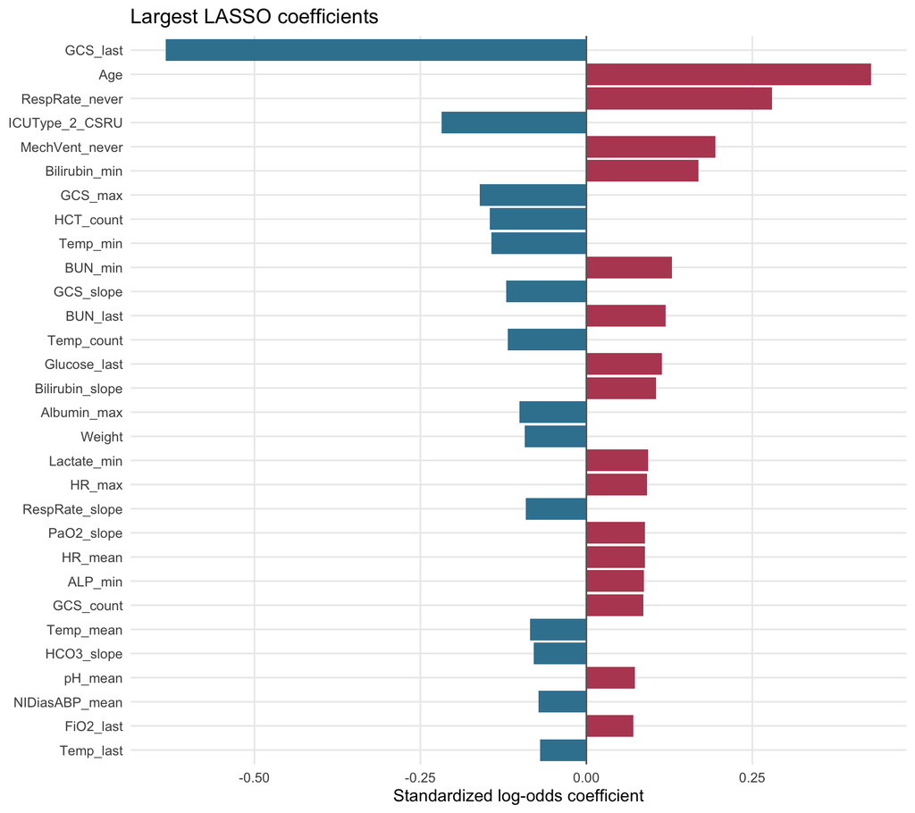

Largest non-zero coefficients from the LASSO refit on all set-a. Predictors were standardized, so coefficient magnitudes are comparable.

```r
coefficient_plot_data <- coefficient_table |>
  slice_head(n = 30L) |>
  mutate(predictor = factor(predictor, levels = rev(predictor)))

ggplot(coefficient_plot_data, aes(x = coefficient, y = predictor, fill = coefficient > 0)) +
  geom_col(show.legend = FALSE) +
  geom_vline(xintercept = 0, color = "grey40") +
  scale_fill_manual(values = c("#3B82A0", "#B84A62")) +
  labs(
    x = "Standardized log-odds coefficient",
    y = NULL,
    title = "Largest LASSO coefficients"
  )
```

The plot shows which standardized features contribute most strongly after simultaneous shrinkage. Positive coefficients increase predicted mortality and negative coefficients decrease it, conditional on the other retained features; they are predictive associations, not causal effects.

```r
knitr::kable(
  stability_table |>
    slice_head(n = 30L),
  caption = "Thirty most frequently selected LASSO predictors across outer folds"
)
```

Thirty most frequently selected LASSO predictors across outer folds

| predictor | selected_folds | selection_percent | selected_in_final |
| --- | --- | --- | --- |
| ALP_min | 5 | 100 | TRUE |
| Age | 5 | 100 | TRUE |
| Albumin_max | 5 | 100 | TRUE |
| BUN_last | 5 | 100 | TRUE |
| BUN_min | 5 | 100 | TRUE |
| Bilirubin_slope | 5 | 100 | TRUE |
| DiasABP_last | 5 | 100 | TRUE |
| GCS_count | 5 | 100 | TRUE |
| GCS_last | 5 | 100 | TRUE |
| GCS_max | 5 | 100 | TRUE |
| GCS_slope | 5 | 100 | TRUE |
| Glucose_last | 5 | 100 | TRUE |
| HCO3_slope | 5 | 100 | TRUE |
| HCT_count | 5 | 100 | TRUE |
| HR_max | 5 | 100 | TRUE |
| HR_mean | 5 | 100 | TRUE |
| ICUType_2_CSRU | 5 | 100 | TRUE |
| Lactate_slope | 5 | 100 | TRUE |
| Mg_slope | 5 | 100 | TRUE |
| NIDiasABP_mean | 5 | 100 | TRUE |
| PaO2_max | 5 | 100 | TRUE |
| PaO2_slope | 5 | 100 | TRUE |
| RespRate_never | 5 | 100 | TRUE |
| RespRate_slope | 5 | 100 | TRUE |
| Temp_count | 5 | 100 | TRUE |
| Temp_last | 5 | 100 | TRUE |
| Temp_min | 5 | 100 | TRUE |
| Urine_max | 5 | 100 | TRUE |
| WBC_never | 5 | 100 | TRUE |
| Weight | 5 | 100 | TRUE |

The table complements the coefficient plot by showing reproducibility across patient splits: predictors appearing in all or most folds are more stable than those selected only once, although stability still does not imply causality.

# GAM partial effects

```r
final_gam_features <- intersect(gam_features, final_training_keep)
final_gam_prep <- fit_preprocessor(
  x_raw[final_gam_features],
  scale = FALSE
)
final_gam_x <- apply_preprocessor(
  final_gam_prep,
  x_raw[final_gam_features]
)
final_gam_formula <- make_gam_formula(
  intersect(gam_continuous, names(final_gam_x)),
  intersect(gam_linear, names(final_gam_x))
)
final_gam_fit <- mgcv::gam(
  final_gam_formula,
  data = data.frame(outcome = y, final_gam_x, check.names = FALSE),
  family = binomial(),
  method = "REML",
  select = TRUE
)

effect_variables <- intersect(c("Age", "HR_mean", "Temp_mean"), gam_continuous)

make_effect_data <- function(variable) {
  base_values <- vapply(final_gam_x, median, numeric(1))
  grid <- seq(
    quantile(final_gam_x[[variable]], 0.05),
    quantile(final_gam_x[[variable]], 0.95),
    length.out = 100
  )
  newdata <- as.data.frame(matrix(
    rep(base_values, each = length(grid)),
    nrow = length(grid),
    dimnames = list(NULL, names(base_values))
  ))
  newdata[[variable]] <- grid
  term_prediction <- predict(
    final_gam_fit,
    newdata = newdata,
    type = "terms",
    se.fit = TRUE
  )
  term_name <- grep(
    paste0("^s\\(", variable, "\\)"),
    colnames(term_prediction$fit),
    value = TRUE
  )[[1]]
  tibble(
    predictor = variable,
    value = grid,
    centered_log_odds = term_prediction$fit[, term_name],
    se = term_prediction$se.fit[, term_name],
    lower = centered_log_odds - 1.96 * se,
    upper = centered_log_odds + 1.96 * se
  )
}

gam_effects <- bind_rows(lapply(effect_variables, make_effect_data))

gam_edf <- as.data.frame(summary(final_gam_fit)$s.table) |>
  tibble::rownames_to_column("term") |>
  transmute(
    term,
    edf = edf,
    p_value = `p-value`
  )

effect_edf <- function(variable) {
  row <- gam_edf[grepl(paste0("^s\\(", variable, "\\)"), gam_edf$term), ]
  if (nrow(row) == 0L) return(NA_real_)
  row$edf[[1]]
}

shape_label <- function(variable) {
  e <- gam_effects |> filter(predictor == variable)
  low <- e$centered_log_odds[[1]]
  mid <- e$centered_log_odds[[ceiling(nrow(e) / 2)]]
  high <- e$centered_log_odds[[nrow(e)]]
  if (low > mid && high > mid) return("a U-shaped pattern")
  if (low < mid && high < mid) return("an inverted-U pattern")
  if (high > low) return("an overall increasing pattern")
  "an overall decreasing pattern"
}
```

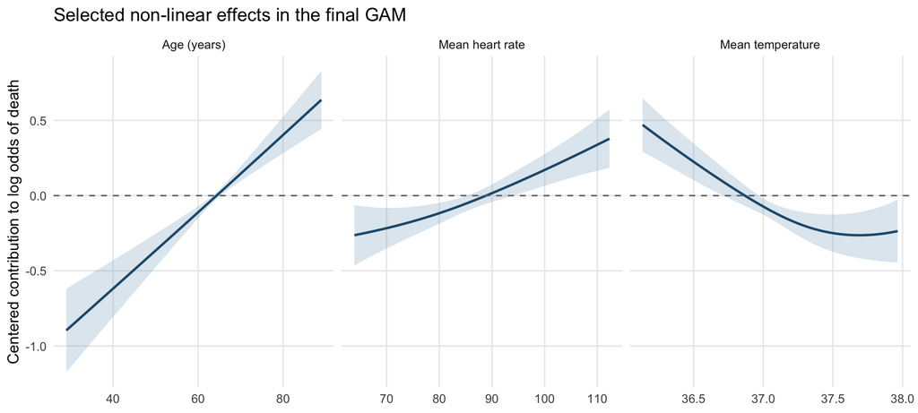

Centered GAM smooths on the log-odds scale. Bands are approximate 95% confidence intervals; other predictors are held at their medians.

```r
effect_labels <- c(
  Age = "Age (years)",
  HR_mean = "Mean heart rate",
  Temp_mean = "Mean temperature"
)

ggplot(gam_effects, aes(x = value, y = centered_log_odds)) +
  geom_ribbon(aes(ymin = lower, ymax = upper), fill = "#7AA6C2", alpha = 0.25) +
  geom_line(color = "#235A7C", linewidth = 0.9) +
  geom_hline(yintercept = 0, linetype = 2, color = "grey45") +
  facet_wrap(
    ~ predictor,
    scales = "free_x",
    labeller = as_labeller(effect_labels)
  ) +
  labs(
    x = NULL,
    y = "Centered contribution to log odds of death",
    title = "Selected non-linear effects in the final GAM"
  )
```

Age has an effective degrees of freedom (EDF) of 1.02 and shows an overall increasing pattern. Its EDF is close to one, so the effect is approximately linear; increasing risk with age is clinically plausible because physiologic reserve generally declines. Mean heart rate has EDF 1.51 and shows an overall increasing pattern. The modest curvature and overall increase are clinically plausible because tachycardia can mark physiologic stress, although the fitted curve does not show a strong separate rise at the bradycardic end. Mean temperature has EDF 2.21 and shows an overall decreasing pattern. This is meaningfully non-linear; higher risk at the low-temperature end is clinically plausible in severe illness, while the expected high-fever upturn is not strongly supported over the central 90% of observed values. These statements describe predictive patterns and do not imply causal effects.

# 2.7 Model comparison and final choice

```r
model_order <- c("LASSO", "GAM", "RandomForest", "SAPS_I", "SOFA")

comparison_summary <- fold_metrics |>
  mutate(model = factor(model, levels = model_order)) |>
  group_by(model) |>
  summarise(
    mean_AUROC = mean(AUROC),
    sd_AUROC = sd(AUROC),
    .groups = "drop"
  ) |>
  arrange(desc(mean_AUROC))

comparison_table <- fold_metrics |>
  mutate(
    model = factor(model, levels = model_order),
    Fold = paste0("Fold ", fold),
    AUROC = round(AUROC, 3)
  ) |>
  select(model, Fold, AUROC) |>
  pivot_wider(names_from = Fold, values_from = AUROC) |>
  left_join(
    comparison_summary |>
      mutate(
        mean_AUROC = round(mean_AUROC, 3),
        sd_AUROC = round(sd_AUROC, 3)
      ),
    by = "model"
  ) |>
  arrange(match(model, model_order))

knitr::kable(
  comparison_table,
  caption = "Outer-fold AUROC for the three models and two benchmark scores"
)
```

Outer-fold AUROC for the three models and two benchmark scores

| model | Fold 1 | Fold 2 | Fold 3 | Fold 4 | Fold 5 | mean_AUROC | sd_AUROC |
| --- | --- | --- | --- | --- | --- | --- | --- |
| LASSO | 0.838 | 0.840 | 0.828 | 0.871 | 0.847 | 0.845 | 0.016 |
| GAM | 0.816 | 0.828 | 0.830 | 0.862 | 0.826 | 0.832 | 0.017 |
| RandomForest | 0.854 | 0.823 | 0.830 | 0.847 | 0.853 | 0.842 | 0.014 |
| SAPS_I | 0.624 | 0.663 | 0.605 | 0.663 | 0.635 | 0.638 | 0.025 |
| SOFA | 0.665 | 0.636 | 0.639 | 0.597 | 0.597 | 0.627 | 0.029 |

The comparison table places every method on the identical five held-out folds. LASSO has the highest mean AUROC; the standard deviations quantify how much discrimination varies across patient splits rather than hiding that variation behind a single pooled estimate.

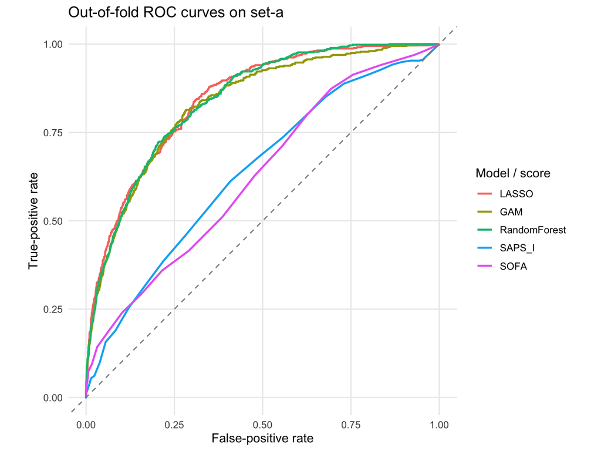

Receiver operating characteristic curves from out-of-fold predictions. Every stay is scored by a model that was not trained on that stay.

```r
roc_data <- oof_predictions |>
  pivot_longer(
    cols = all_of(model_order),
    names_to = "model",
    values_to = "score"
  ) |>
  group_by(model) |>
  group_modify(~ {
    roc_object <- pROC::roc(
      .x$truth, .x$score,
      levels = c(0, 1),
      direction = "<",
      quiet = TRUE
    )
    coords <- pROC::coords(
      roc_object,
      x = "all",
      ret = c("specificity", "sensitivity"),
      transpose = FALSE
    )
    as_tibble(coords)
  }) |>
  ungroup() |>
  mutate(model = factor(model, levels = model_order))

ggplot(roc_data, aes(x = 1 - specificity, y = sensitivity, color = model)) +
  geom_path(linewidth = 0.9) +
  geom_abline(slope = 1, intercept = 0, linetype = 2, color = "grey55") +
  coord_equal() +
  labs(
    x = "False-positive rate",
    y = "True-positive rate",
    color = "Model / score",
    title = "Out-of-fold ROC curves on set-a"
  )
```

The out-of-fold receiver operating characteristic curves show that the three fitted models separate deaths from survivors substantially better than either benchmark across most false-positive rates. Each curve uses predictions made for stays that were excluded from the corresponding model fit.

```r
candidate_summary <- comparison_summary |>
  filter(model %in% c("LASSO", "GAM", "RandomForest")) |>
  mutate(model = as.character(model))

best_model <- candidate_summary$model[[which.max(candidate_summary$mean_AUROC)]]
best_auc <- max(candidate_summary$mean_AUROC)
best_model_sd <- candidate_summary$sd_AUROC[[
  which.max(candidate_summary$mean_AUROC)
]]
lasso_auc <- candidate_summary$mean_AUROC[candidate_summary$model == "LASSO"]

benchmark_summary <- comparison_summary |>
  filter(model %in% c("SAPS_I", "SOFA")) |>
  mutate(model = as.character(model))
best_benchmark_row <- which.max(benchmark_summary$mean_AUROC)
best_benchmark_name <- benchmark_summary$model[[best_benchmark_row]]
best_benchmark_auc <- benchmark_summary$mean_AUROC[[best_benchmark_row]]
best_benchmark_sd <- benchmark_summary$sd_AUROC[[best_benchmark_row]]
benchmark_gap <- best_auc - best_benchmark_auc

final_model_name <- if (lasso_auc >= best_auc - 0.01) "LASSO" else best_model

# Refit random forest on all set-a so it is available if selected.
full_rf_inner <- make_stratified_folds(y, inner_k, seed = 77001)
final_rf_best <- tune_rf(x_raw, y, full_rf_inner, seed = 78001)
final_rf_prep <- fit_preprocessor(
  x_raw[final_training_keep],
  scale = FALSE
)
final_rf_x <- apply_preprocessor(
  final_rf_prep,
  x_raw[final_training_keep]
)
final_rf_fit <- fit_one_rf(
  final_rf_x, y,
  mtry = min(final_rf_best$mtry[[1]], ncol(final_rf_x)),
  min_node = final_rf_best$min.node.size[[1]],
  seed = 79001
)

final_object <- switch(
  final_model_name,
  LASSO = list(
    model_name = "LASSO",
    fit = final_lasso_fit,
    preprocessor = final_lasso_prep,
    lambda = final_lasso_tuning$lambda,
    predictor_columns = names(final_lasso_prep$medians),
    feature_threshold = rare_measurement_threshold,
    kept_parameters = kept_parameters
  ),
  GAM = list(
    model_name = "GAM",
    fit = final_gam_fit,
    preprocessor = final_gam_prep,
    gam_features = final_gam_features,
    predictor_columns = names(final_gam_prep$medians),
    feature_threshold = rare_measurement_threshold,
    kept_parameters = kept_parameters
  ),
  RandomForest = list(
    model_name = "RandomForest",
    fit = final_rf_fit,
    preprocessor = final_rf_prep,
    tuning = final_rf_best,
    predictor_columns = names(final_rf_prep$medians),
    feature_threshold = rare_measurement_threshold,
    kept_parameters = kept_parameters
  )
)

saveRDS(final_object, file.path(out_dir, "cp2_final_model.rds"))

stopifnot(
  file.exists(file.path(out_dir, "cp2_final_model.rds")),
  file.exists(file.path(out_dir, "cp2_oof_predictions.csv"))
)
```

The highest mean outer-fold AUROC among the three fitted models was LASSO (0.845). LASSO achieved 0.845. I selected **LASSO** as the final model: LASSO is preferred when it is within 0.01 AUROC of the best model because its sparse standardized coefficients are substantially easier to inspect; otherwise the empirically best model is retained. This rule was stated before examining set-b or set-c, neither of which is read here.

The strongest benchmark was SAPS_I, with mean AUROC 0.638 and fold-to-fold standard deviation 0.025. The best fitted model exceeds it by 0.207 AUROC. This gap is **larger** than the larger of the two fold-to-fold standard deviations (0.025). Therefore, the improvement over SAPS-I and SOFA is much larger than ordinary fold-to-fold variation in this analysis. This supports a discrimination advantage on set-a, but it does not establish clinical usefulness or external validity; those require Checkpoint 3.

# Output and reproducibility checks

```r
required_outputs <- c(
  file.path(out_dir, "cp2_final_model.rds"),
  file.path(out_dir, "cp2_oof_predictions.csv")
)

stopifnot(
  all(file.exists(required_outputs)),
  all(file.info(required_outputs)$size > 0),
  nrow(oof_predictions) == expected_n,
  !anyDuplicated(oof_predictions$RecordID)
)

tibble(
  Output = basename(required_outputs),
  `Size (MB)` = round(file.info(required_outputs)$size / 1024^2, 2)
) |>
  knitr::kable(caption = "Checkpoint 2 artifacts saved for Checkpoint 3")
```

Checkpoint 2 artifacts saved for Checkpoint 3

| Output | Size (MB) |
| --- | --- |
| cp2_final_model.rds | 0.01 |
| cp2_oof_predictions.csv | 0.28 |

The out-of-fold file contains one prediction per stay for all three models and both benchmark scores. The saved final-model object contains the fitted model, its training-derived preprocessing values, and the feature specification needed to apply the same transformation in Checkpoint 3.